# Risk Factor Analysis

## Outcome Variable

**Outcome Variable:** wast_rec90d

## Predictor Variables

**Intervention Variable:** perdiar6

**Adjustment Set:**

- arm
- sex
- W_mage
- meducyrs
- hfoodsec
- W_mhtcm
- W_mwtkg
- W_mbmi
- W_birthwt
- W_birthlen
- W_nrooms
- month
- brthmon
- impfloor
- impsan
- safeh20
- delta_W_mage
- delta_meducyrs
- delta_hfoodsec
- delta_W_mhtcm
- delta_W_mwtkg
- delta_W_mbmi
- delta_W_birthwt
- delta_W_birthlen
- delta_W_nrooms
- delta_month
- delta_brthmon
- delta_impfloor
- delta_impsan
- delta_safeh20

## Stratifying Variables

The analysis was stratified on these variable(s):

- agecat
- studyid
- country

## Data Summary

| agecat | studyid | country | perdiar6 | wast_rec90d | n_cell | n |
| --- | --- | --- | --- | --- | --- | --- |
| 0-24 months | CMIN | BANGLADESH | 0% | 0 | 28 | 190 |
| 0-24 months | CMIN | BANGLADESH | 0% | 1 | 43 | 190 |
| 0-24 months | CMIN | BANGLADESH | (0%, 5%] | 0 | 19 | 190 |
| 0-24 months | CMIN | BANGLADESH | (0%, 5%] | 1 | 16 | 190 |
| 0-24 months | CMIN | BANGLADESH | >5% | 0 | 33 | 190 |
| 0-24 months | CMIN | BANGLADESH | >5% | 1 | 51 | 190 |
| 0-24 months | CONTENT | PERU | 0% | 0 | 0 | 7 |
| 0-24 months | CONTENT | PERU | 0% | 1 | 1 | 7 |
| 0-24 months | CONTENT | PERU | (0%, 5%] | 0 | 0 | 7 |
| 0-24 months | CONTENT | PERU | (0%, 5%] | 1 | 1 | 7 |
| 0-24 months | CONTENT | PERU | >5% | 0 | 1 | 7 |
| 0-24 months | CONTENT | PERU | >5% | 1 | 4 | 7 |
| 0-24 months | EE | PAKISTAN | 0% | 0 | 149 | 323 |
| 0-24 months | EE | PAKISTAN | 0% | 1 | 141 | 323 |
| 0-24 months | EE | PAKISTAN | (0%, 5%] | 0 | 11 | 323 |
| 0-24 months | EE | PAKISTAN | (0%, 5%] | 1 | 18 | 323 |
| 0-24 months | EE | PAKISTAN | >5% | 0 | 0 | 323 |
| 0-24 months | EE | PAKISTAN | >5% | 1 | 4 | 323 |
| 0-24 months | MAL-ED | BANGLADESH | 0% | 0 | 16 | 124 |
| 0-24 months | MAL-ED | BANGLADESH | 0% | 1 | 22 | 124 |
| 0-24 months | MAL-ED | BANGLADESH | (0%, 5%] | 0 | 20 | 124 |
| 0-24 months | MAL-ED | BANGLADESH | (0%, 5%] | 1 | 34 | 124 |
| 0-24 months | MAL-ED | BANGLADESH | >5% | 0 | 8 | 124 |
| 0-24 months | MAL-ED | BANGLADESH | >5% | 1 | 24 | 124 |
| 0-24 months | MAL-ED | BRAZIL | 0% | 0 | 5 | 24 |
| 0-24 months | MAL-ED | BRAZIL | 0% | 1 | 16 | 24 |
| 0-24 months | MAL-ED | BRAZIL | (0%, 5%] | 0 | 0 | 24 |
| 0-24 months | MAL-ED | BRAZIL | (0%, 5%] | 1 | 2 | 24 |
| 0-24 months | MAL-ED | BRAZIL | >5% | 0 | 1 | 24 |
| 0-24 months | MAL-ED | BRAZIL | >5% | 1 | 0 | 24 |

[output cut: 204 more lines]

The following strata were considered:

- agecat: 0-24 months, studyid: CMIN, country: BANGLADESH
- agecat: 0-24 months, studyid: CONTENT, country: PERU
- agecat: 0-24 months, studyid: EE, country: PAKISTAN
- agecat: 0-24 months, studyid: MAL-ED, country: BANGLADESH
- agecat: 0-24 months, studyid: MAL-ED, country: BRAZIL
- agecat: 0-24 months, studyid: MAL-ED, country: INDIA
- agecat: 0-24 months, studyid: MAL-ED, country: NEPAL
- agecat: 0-24 months, studyid: MAL-ED, country: PERU
- agecat: 0-24 months, studyid: MAL-ED, country: SOUTH AFRICA
- agecat: 0-24 months, studyid: MAL-ED, country: TANZANIA, UNITED REPUBLIC OF
- agecat: 0-24 months, studyid: NIH-Birth, country: BANGLADESH
- agecat: 0-24 months, studyid: NIH-Crypto, country: BANGLADESH
- agecat: 0-24 months, studyid: PROVIDE, country: BANGLADESH
- agecat: 0-6 months, studyid: CMIN, country: BANGLADESH
- agecat: 0-6 months, studyid: CONTENT, country: PERU
- agecat: 0-6 months, studyid: EE, country: PAKISTAN
- agecat: 0-6 months, studyid: MAL-ED, country: BANGLADESH
- agecat: 0-6 months, studyid: MAL-ED, country: BRAZIL
- agecat: 0-6 months, studyid: MAL-ED, country: INDIA
- agecat: 0-6 months, studyid: MAL-ED, country: NEPAL
- agecat: 0-6 months, studyid: MAL-ED, country: PERU
- agecat: 0-6 months, studyid: MAL-ED, country: SOUTH AFRICA
- agecat: 0-6 months, studyid: MAL-ED, country: TANZANIA, UNITED REPUBLIC OF
- agecat: 0-6 months, studyid: NIH-Birth, country: BANGLADESH
- agecat: 0-6 months, studyid: NIH-Crypto, country: BANGLADESH
- agecat: 0-6 months, studyid: PROVIDE, country: BANGLADESH
- agecat: 6-24 months, studyid: CMIN, country: BANGLADESH
- agecat: 6-24 months, studyid: CONTENT, country: PERU
- agecat: 6-24 months, studyid: EE, country: PAKISTAN
- agecat: 6-24 months, studyid: MAL-ED, country: BANGLADESH
- agecat: 6-24 months, studyid: MAL-ED, country: BRAZIL
- agecat: 6-24 months, studyid: MAL-ED, country: INDIA
- agecat: 6-24 months, studyid: MAL-ED, country: NEPAL
- agecat: 6-24 months, studyid: MAL-ED, country: PERU
- agecat: 6-24 months, studyid: MAL-ED, country: SOUTH AFRICA
- agecat: 6-24 months, studyid: MAL-ED, country: TANZANIA, UNITED REPUBLIC OF
- agecat: 6-24 months, studyid: NIH-Birth, country: BANGLADESH
- agecat: 6-24 months, studyid: NIH-Crypto, country: BANGLADESH
- agecat: 6-24 months, studyid: PROVIDE, country: BANGLADESH

### Dropped Strata

Some strata were dropped due to rare outcomes:

- agecat: 0-24 months, studyid: CONTENT, country: PERU
- agecat: 0-24 months, studyid: EE, country: PAKISTAN
- agecat: 0-24 months, studyid: MAL-ED, country: BRAZIL
- agecat: 0-24 months, studyid: MAL-ED, country: NEPAL
- agecat: 0-24 months, studyid: MAL-ED, country: PERU
- agecat: 0-24 months, studyid: MAL-ED, country: SOUTH AFRICA
- agecat: 0-24 months, studyid: MAL-ED, country: TANZANIA, UNITED REPUBLIC OF
- agecat: 0-6 months, studyid: CONTENT, country: PERU
- agecat: 0-6 months, studyid: EE, country: PAKISTAN
- agecat: 0-6 months, studyid: MAL-ED, country: BANGLADESH
- agecat: 0-6 months, studyid: MAL-ED, country: BRAZIL
- agecat: 0-6 months, studyid: MAL-ED, country: NEPAL
- agecat: 0-6 months, studyid: MAL-ED, country: PERU
- agecat: 0-6 months, studyid: MAL-ED, country: SOUTH AFRICA
- agecat: 0-6 months, studyid: MAL-ED, country: TANZANIA, UNITED REPUBLIC OF
- agecat: 6-24 months, studyid: CONTENT, country: PERU
- agecat: 6-24 months, studyid: EE, country: PAKISTAN
- agecat: 6-24 months, studyid: MAL-ED, country: BRAZIL
- agecat: 6-24 months, studyid: MAL-ED, country: NEPAL
- agecat: 6-24 months, studyid: MAL-ED, country: PERU
- agecat: 6-24 months, studyid: MAL-ED, country: SOUTH AFRICA
- agecat: 6-24 months, studyid: MAL-ED, country: TANZANIA, UNITED REPUBLIC OF
- agecat: 6-24 months, studyid: NIH-Crypto, country: BANGLADESH

## Methods Detail

We’re interested in the causal parameters $E[Y_a]$ for all values of $a \in \mathcal{A}$. These parameters represent the mean outcome if, possibly contrary to fact, we intervened to set all units to have $A=a$. Under the randomization and positivity assumptions, these are identified by the statistical parameters $\psi_a=E_W[E_{Y|A,W}(Y|A=a,W)]$. In addition, we’re interested in the mean of $Y$, $E[Y]$ under no intervention (the observed mean). We will estimate these parameters by using SuperLearner to fit the relevant likelihood factors – $E_{Y|A,W}(Y|A=a,W)$ and $p(A=a|W)$, and then updating our likelihood fit using a joint TMLE.

For unadjusted analyses ($W=\{\}$), initial likelihoods were estimated using Lrnr_glm to estimate the simple $E(Y|A)$ and Lrnr_mean to estimate $p(A)$. For adjusted analyses, a small library containing Lrnr_glmnet, Lrnr_xgboost, and Lrnr_mean was used.

Having estimated these parameters, we will then use the delta method to estimate relative risks and attributable risks relative to a prespecified baseline level of $A$.

# Results Detail

## Results Plots

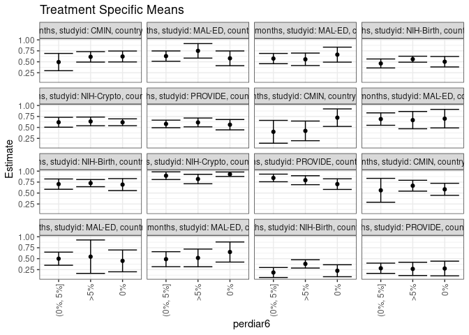

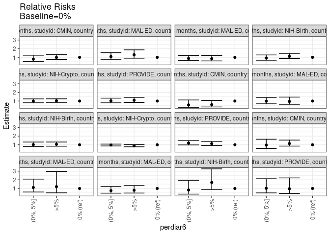

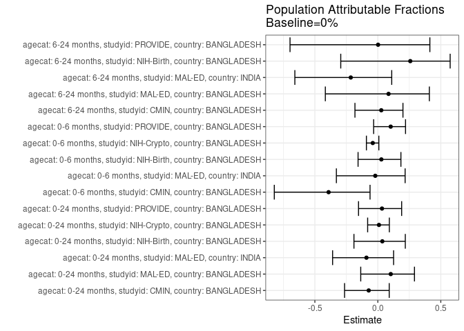

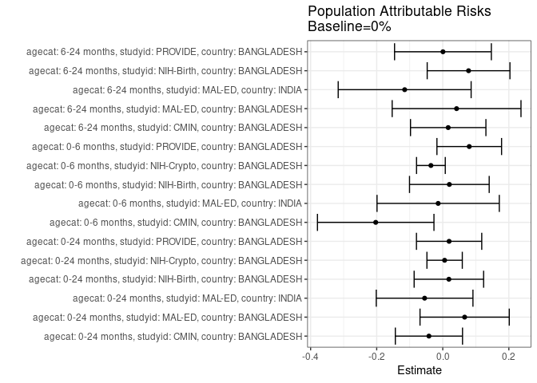

## Results Table

### Parameter: TSM

| agecat | studyid | country | intervention_level | baseline_level | estimate | ci_lower | ci_upper |
| --- | --- | --- | --- | --- | --- | --- | --- |
| 0-24 months | CMIN | BANGLADESH | 0% | NA | 0.6208388 | 0.4962683 | 0.7454094 |
| 0-24 months | CMIN | BANGLADESH | (0%, 5%] | NA | 0.4935285 | 0.2966957 | 0.6903612 |
| 0-24 months | CMIN | BANGLADESH | >5% | NA | 0.6127808 | 0.4936258 | 0.7319358 |
| 0-24 months | MAL-ED | BANGLADESH | 0% | NA | 0.5789474 | 0.4106093 | 0.7472854 |
| 0-24 months | MAL-ED | BANGLADESH | (0%, 5%] | NA | 0.6296296 | 0.5121519 | 0.7471074 |
| 0-24 months | MAL-ED | BANGLADESH | >5% | NA | 0.7500000 | 0.5844253 | 0.9155747 |
| 0-24 months | MAL-ED | INDIA | 0% | NA | 0.6627065 | 0.4915503 | 0.8338627 |
| 0-24 months | MAL-ED | INDIA | (0%, 5%] | NA | 0.5732784 | 0.4563143 | 0.6902425 |
| 0-24 months | MAL-ED | INDIA | >5% | NA | 0.5564866 | 0.4145523 | 0.6984209 |
| 0-24 months | NIH-Birth | BANGLADESH | 0% | NA | 0.5016833 | 0.3819397 | 0.6214268 |
| 0-24 months | NIH-Birth | BANGLADESH | (0%, 5%] | NA | 0.4617738 | 0.3594909 | 0.5640566 |
| 0-24 months | NIH-Birth | BANGLADESH | >5% | NA | 0.5587479 | 0.4908477 | 0.6266480 |
| 0-24 months | NIH-Crypto | BANGLADESH | 0% | NA | 0.6169799 | 0.5389807 | 0.6949791 |
| 0-24 months | NIH-Crypto | BANGLADESH | (0%, 5%] | NA | 0.6175651 | 0.5047303 | 0.7303998 |
| 0-24 months | NIH-Crypto | BANGLADESH | >5% | NA | 0.6372161 | 0.5384984 | 0.7359339 |
| 0-24 months | PROVIDE | BANGLADESH | 0% | NA | 0.5619994 | 0.4442231 | 0.6797757 |
| 0-24 months | PROVIDE | BANGLADESH | (0%, 5%] | NA | 0.5793274 | 0.4930909 | 0.6655640 |
| 0-24 months | PROVIDE | BANGLADESH | >5% | NA | 0.6135162 | 0.5129340 | 0.7140984 |
| 0-6 months | CMIN | BANGLADESH | 0% | NA | 0.7222222 | 0.5220936 | 0.9223508 |
| 0-6 months | CMIN | BANGLADESH | (0%, 5%] | NA | 0.4000000 | 0.1395476 | 0.6604524 |
| 0-6 months | CMIN | BANGLADESH | >5% | NA | 0.4210526 | 0.1965983 | 0.6455070 |
| 0-6 months | MAL-ED | INDIA | 0% | NA | 0.7000000 | 0.4880703 | 0.9119297 |
| 0-6 months | MAL-ED | INDIA | (0%, 5%] | NA | 0.6904762 | 0.5490691 | 0.8318832 |
| 0-6 months | MAL-ED | INDIA | >5% | NA | 0.6666667 | 0.4697615 | 0.8635719 |
| 0-6 months | NIH-Birth | BANGLADESH | 0% | NA | 0.6930760 | 0.5562350 | 0.8299170 |
| 0-6 months | NIH-Birth | BANGLADESH | (0%, 5%] | NA | 0.7038637 | 0.5862341 | 0.8214933 |
| 0-6 months | NIH-Birth | BANGLADESH | >5% | NA | 0.7265867 | 0.6446334 | 0.8085399 |
| 0-6 months | NIH-Crypto | BANGLADESH | 0% | NA | 0.9292929 | 0.8781896 | 0.9803962 |
| 0-6 months | NIH-Crypto | BANGLADESH | (0%, 5%] | NA | 0.8958333 | 0.8083040 | 0.9833626 |
| 0-6 months | NIH-Crypto | BANGLADESH | >5% | NA | 0.8200000 | 0.7121415 | 0.9278585 |
| 0-6 months | PROVIDE | BANGLADESH | 0% | NA | 0.7036355 | 0.5821528 | 0.8251182 |
| 0-6 months | PROVIDE | BANGLADESH | (0%, 5%] | NA | 0.8443270 | 0.7572959 | 0.9313581 |
| 0-6 months | PROVIDE | BANGLADESH | >5% | NA | 0.7929170 | 0.6907735 | 0.8950605 |
| 6-24 months | CMIN | BANGLADESH | 0% | NA | 0.5849847 | 0.4476029 | 0.7223665 |
| 6-24 months | CMIN | BANGLADESH | (0%, 5%] | NA | 0.5624248 | 0.2900798 | 0.8347699 |
| 6-24 months | CMIN | BANGLADESH | >5% | NA | 0.6674888 | 0.5434810 | 0.7914965 |
| 6-24 months | MAL-ED | BANGLADESH | 0% | NA | 0.4500000 | 0.2011920 | 0.6988080 |
| 6-24 months | MAL-ED | BANGLADESH | (0%, 5%] | NA | 0.5000000 | 0.3500866 | 0.6499134 |
| 6-24 months | MAL-ED | BANGLADESH | >5% | NA | 0.5454545 | 0.1641333 | 0.9267758 |
| 6-24 months | MAL-ED | INDIA | 0% | NA | 0.6521739 | 0.4227678 | 0.8815800 |
| 6-24 months | MAL-ED | INDIA | (0%, 5%] | NA | 0.4883721 | 0.3173946 | 0.6593495 |
| 6-24 months | MAL-ED | INDIA | >5% | NA | 0.5172414 | 0.3159219 | 0.7185608 |
| 6-24 months | NIH-Birth | BANGLADESH | 0% | NA | 0.2249275 | 0.0881910 | 0.3616640 |
| 6-24 months | NIH-Birth | BANGLADESH | (0%, 5%] | NA | 0.1847166 | 0.0708381 | 0.2985952 |
| 6-24 months | NIH-Birth | BANGLADESH | >5% | NA | 0.3813221 | 0.2862032 | 0.4764410 |
| 6-24 months | PROVIDE | BANGLADESH | 0% | NA | 0.2758621 | 0.1082883 | 0.4434359 |
| 6-24 months | PROVIDE | BANGLADESH | (0%, 5%] | NA | 0.2812500 | 0.1643962 | 0.3981038 |
| 6-24 months | PROVIDE | BANGLADESH | >5% | NA | 0.2666667 | 0.1154539 | 0.4178794 |

### Parameter: E(Y)

| agecat | studyid | country | intervention_level | baseline_level | estimate | ci_lower | ci_upper |
| --- | --- | --- | --- | --- | --- | --- | --- |
| 0-24 months | CMIN | BANGLADESH | NA | NA | 0.5789474 | 0.5004470 | 0.6574477 |
| 0-24 months | MAL-ED | BANGLADESH | NA | NA | 0.6451613 | 0.5593015 | 0.7310211 |
| 0-24 months | MAL-ED | INDIA | NA | NA | 0.6077348 | 0.5286689 | 0.6868008 |
| 0-24 months | NIH-Birth | BANGLADESH | NA | NA | 0.5201900 | 0.4695846 | 0.5707955 |
| 0-24 months | NIH-Crypto | BANGLADESH | NA | NA | 0.6225806 | 0.5684562 | 0.6767051 |
| 0-24 months | PROVIDE | BANGLADESH | NA | NA | 0.5811688 | 0.5245443 | 0.6377934 |
| 0-6 months | CMIN | BANGLADESH | NA | NA | 0.5192308 | 0.3806687 | 0.6577929 |
| 0-6 months | MAL-ED | INDIA | NA | NA | 0.6860465 | 0.5849088 | 0.7871842 |
| 0-6 months | NIH-Birth | BANGLADESH | NA | NA | 0.7130045 | 0.6535890 | 0.7724200 |
| 0-6 months | NIH-Crypto | BANGLADESH | NA | NA | 0.8934010 | 0.8497799 | 0.9370221 |
| 0-6 months | PROVIDE | BANGLADESH | NA | NA | 0.7837838 | 0.7252863 | 0.8422812 |
| 6-24 months | CMIN | BANGLADESH | NA | NA | 0.6014493 | 0.5131344 | 0.6897641 |
| 6-24 months | MAL-ED | BANGLADESH | NA | NA | 0.4918033 | 0.3610932 | 0.6225134 |
| 6-24 months | MAL-ED | INDIA | NA | NA | 0.5368421 | 0.4223932 | 0.6512910 |
| 6-24 months | NIH-Birth | BANGLADESH | NA | NA | 0.3030303 | 0.2377927 | 0.3682679 |
| 6-24 months | PROVIDE | BANGLADESH | NA | NA | 0.2764228 | 0.1950773 | 0.3577682 |

### Parameter: RR

| agecat | studyid | country | intervention_level | baseline_level | estimate | ci_lower | ci_upper |
| --- | --- | --- | --- | --- | --- | --- | --- |
| 0-24 months | CMIN | BANGLADESH | 0% | 0% | 1.0000000 | 1.0000000 | 1.000000 |
| 0-24 months | CMIN | BANGLADESH | (0%, 5%] | 0% | 0.7949382 | 0.5086007 | 1.242481 |
| 0-24 months | CMIN | BANGLADESH | >5% | 0% | 0.9870208 | 0.7465608 | 1.304930 |
| 0-24 months | MAL-ED | BANGLADESH | 0% | 0% | 1.0000000 | 1.0000000 | 1.000000 |
| 0-24 months | MAL-ED | BANGLADESH | (0%, 5%] | 0% | 1.0875421 | 0.7699799 | 1.536076 |
| 0-24 months | MAL-ED | BANGLADESH | >5% | 0% | 1.2954545 | 0.8993242 | 1.866071 |
| 0-24 months | MAL-ED | INDIA | 0% | 0% | 1.0000000 | 1.0000000 | 1.000000 |
| 0-24 months | MAL-ED | INDIA | (0%, 5%] | 0% | 0.8650562 | 0.6237122 | 1.199788 |
| 0-24 months | MAL-ED | INDIA | >5% | 0% | 0.8397180 | 0.5864270 | 1.202411 |
| 0-24 months | NIH-Birth | BANGLADESH | 0% | 0% | 1.0000000 | 1.0000000 | 1.000000 |
| 0-24 months | NIH-Birth | BANGLADESH | (0%, 5%] | 0% | 0.9204488 | 0.6643311 | 1.275307 |
| 0-24 months | NIH-Birth | BANGLADESH | >5% | 0% | 1.1137462 | 0.8524383 | 1.455156 |
| 0-24 months | NIH-Crypto | BANGLADESH | 0% | 0% | 1.0000000 | 1.0000000 | 1.000000 |
| 0-24 months | NIH-Crypto | BANGLADESH | (0%, 5%] | 0% | 1.0009485 | 0.8021632 | 1.248995 |
| 0-24 months | NIH-Crypto | BANGLADESH | >5% | 0% | 1.0327989 | 0.8484017 | 1.257274 |
| 0-24 months | PROVIDE | BANGLADESH | 0% | 0% | 1.0000000 | 1.0000000 | 1.000000 |
| 0-24 months | PROVIDE | BANGLADESH | (0%, 5%] | 0% | 1.0308328 | 0.7966114 | 1.333921 |
| 0-24 months | PROVIDE | BANGLADESH | >5% | 0% | 1.0916670 | 0.8360752 | 1.425394 |
| 0-6 months | CMIN | BANGLADESH | 0% | 0% | 1.0000000 | 1.0000000 | 1.000000 |
| 0-6 months | CMIN | BANGLADESH | (0%, 5%] | 0% | 0.5538462 | 0.2729382 | 1.123865 |
| 0-6 months | CMIN | BANGLADESH | >5% | 0% | 0.5829960 | 0.3197555 | 1.062950 |
| 0-6 months | MAL-ED | INDIA | 0% | 0% | 1.0000000 | 1.0000000 | 1.000000 |
| 0-6 months | MAL-ED | INDIA | (0%, 5%] | 0% | 0.9863946 | 0.6843974 | 1.421651 |
| 0-6 months | MAL-ED | INDIA | >5% | 0% | 0.9523810 | 0.6239074 | 1.453789 |
| 0-6 months | NIH-Birth | BANGLADESH | 0% | 0% | 1.0000000 | 1.0000000 | 1.000000 |
| 0-6 months | NIH-Birth | BANGLADESH | (0%, 5%] | 0% | 1.0155650 | 0.7839752 | 1.315567 |
| 0-6 months | NIH-Birth | BANGLADESH | >5% | 0% | 1.0483506 | 0.8343985 | 1.317163 |
| 0-6 months | NIH-Crypto | BANGLADESH | 0% | 0% | 1.0000000 | 1.0000000 | 1.000000 |
| 0-6 months | NIH-Crypto | BANGLADESH | (0%, 5%] | 0% | 0.9639946 | 0.8617509 | 1.078369 |
| 0-6 months | NIH-Crypto | BANGLADESH | >5% | 0% | 0.8823913 | 0.7651472 | 1.017601 |
| 0-6 months | PROVIDE | BANGLADESH | 0% | 0% | 1.0000000 | 1.0000000 | 1.000000 |
| 0-6 months | PROVIDE | BANGLADESH | (0%, 5%] | 0% | 1.1999494 | 0.9811298 | 1.467572 |
| 0-6 months | PROVIDE | BANGLADESH | >5% | 0% | 1.1268860 | 0.9082676 | 1.398126 |
| 6-24 months | CMIN | BANGLADESH | 0% | 0% | 1.0000000 | 1.0000000 | 1.000000 |
| 6-24 months | CMIN | BANGLADESH | (0%, 5%] | 0% | 0.9614351 | 0.5632496 | 1.641115 |
| 6-24 months | CMIN | BANGLADESH | >5% | 0% | 1.1410363 | 0.8438911 | 1.542810 |
| 6-24 months | MAL-ED | BANGLADESH | 0% | 0% | 1.0000000 | 1.0000000 | 1.000000 |
| 6-24 months | MAL-ED | BANGLADESH | (0%, 5%] | 0% | 1.1111111 | 0.5923791 | 2.084084 |
| 6-24 months | MAL-ED | BANGLADESH | >5% | 0% | 1.2121212 | 0.4972345 | 2.954819 |
| 6-24 months | MAL-ED | INDIA | 0% | 0% | 1.0000000 | 1.0000000 | 1.000000 |
| 6-24 months | MAL-ED | INDIA | (0%, 5%] | 0% | 0.7488372 | 0.4558306 | 1.230188 |
| 6-24 months | MAL-ED | INDIA | >5% | 0% | 0.7931034 | 0.4694408 | 1.339920 |
| 6-24 months | NIH-Birth | BANGLADESH | 0% | 0% | 1.0000000 | 1.0000000 | 1.000000 |
| 6-24 months | NIH-Birth | BANGLADESH | (0%, 5%] | 0% | 0.8212274 | 0.3466570 | 1.945480 |
| 6-24 months | NIH-Birth | BANGLADESH | >5% | 0% | 1.6953112 | 0.8788162 | 3.270400 |
| 6-24 months | PROVIDE | BANGLADESH | 0% | 0% | 1.0000000 | 1.0000000 | 1.000000 |
| 6-24 months | PROVIDE | BANGLADESH | (0%, 5%] | 0% | 1.0195312 | 0.4883689 | 2.128399 |
| 6-24 months | PROVIDE | BANGLADESH | >5% | 0% | 0.9666667 | 0.4210787 | 2.219168 |

### Parameter: PAR

| agecat | studyid | country | intervention_level | baseline_level | estimate | ci_lower | ci_upper |
| --- | --- | --- | --- | --- | --- | --- | --- |
| 0-24 months | CMIN | BANGLADESH | 0% | NA | -0.0418915 | -0.1435748 | 0.0597919 |
| 0-24 months | MAL-ED | BANGLADESH | 0% | NA | 0.0662139 | -0.0688583 | 0.2012861 |
| 0-24 months | MAL-ED | INDIA | 0% | NA | -0.0549717 | -0.2012910 | 0.0913476 |
| 0-24 months | NIH-Birth | BANGLADESH | 0% | NA | 0.0185068 | -0.0866480 | 0.1236616 |
| 0-24 months | NIH-Crypto | BANGLADESH | 0% | NA | 0.0056007 | -0.0479081 | 0.0591096 |
| 0-24 months | PROVIDE | BANGLADESH | 0% | NA | 0.0191694 | -0.0796278 | 0.1179666 |
| 0-6 months | CMIN | BANGLADESH | 0% | NA | -0.2029915 | -0.3793059 | -0.0266770 |
| 0-6 months | MAL-ED | INDIA | 0% | NA | -0.0139535 | -0.1990284 | 0.1711214 |
| 0-6 months | NIH-Birth | BANGLADESH | 0% | NA | 0.0199285 | -0.1006746 | 0.1405315 |
| 0-6 months | NIH-Crypto | BANGLADESH | 0% | NA | -0.0358919 | -0.0793847 | 0.0076008 |
| 0-6 months | PROVIDE | BANGLADESH | 0% | NA | 0.0801483 | -0.0176954 | 0.1779919 |
| 6-24 months | CMIN | BANGLADESH | 0% | NA | 0.0164646 | -0.0976761 | 0.1306052 |
| 6-24 months | MAL-ED | BANGLADESH | 0% | NA | 0.0418033 | -0.1531482 | 0.2367548 |
| 6-24 months | MAL-ED | INDIA | 0% | NA | -0.1153318 | -0.3165243 | 0.0858607 |
| 6-24 months | NIH-Birth | BANGLADESH | 0% | NA | 0.0781028 | -0.0471362 | 0.2033418 |
| 6-24 months | PROVIDE | BANGLADESH | 0% | NA | 0.0005607 | -0.1459375 | 0.1470589 |

### Parameter: PAF

| agecat | studyid | country | intervention_level | baseline_level | estimate | ci_lower | ci_upper |
| --- | --- | --- | --- | --- | --- | --- | --- |
| 0-24 months | CMIN | BANGLADESH | 0% | NA | -0.0723580 | -0.2642274 | 0.0903918 |
| 0-24 months | MAL-ED | BANGLADESH | 0% | NA | 0.1026316 | -0.1357451 | 0.2909764 |
| 0-24 months | MAL-ED | INDIA | 0% | NA | -0.0904534 | -0.3591851 | 0.1251459 |
| 0-24 months | NIH-Birth | BANGLADESH | 0% | NA | 0.0355769 | -0.1896416 | 0.2181579 |
| 0-24 months | NIH-Crypto | BANGLADESH | 0% | NA | 0.0089960 | -0.0808346 | 0.0913606 |
| 0-24 months | PROVIDE | BANGLADESH | 0% | NA | 0.0329843 | -0.1532166 | 0.1891207 |
| 0-6 months | CMIN | BANGLADESH | 0% | NA | -0.3909465 | -0.8220742 | -0.0618295 |
| 0-6 months | MAL-ED | INDIA | 0% | NA | -0.0203390 | -0.3291105 | 0.2167005 |
| 0-6 months | NIH-Birth | BANGLADESH | 0% | NA | 0.0279500 | -0.1569514 | 0.1833008 |
| 0-6 months | NIH-Crypto | BANGLADESH | 0% | NA | -0.0401745 | -0.0906918 | 0.0080031 |
| 0-6 months | PROVIDE | BANGLADESH | 0% | NA | 0.1022582 | -0.0332839 | 0.2200203 |
| 6-24 months | CMIN | BANGLADESH | 0% | NA | 0.0273748 | -0.1817587 | 0.1994984 |
| 6-24 months | MAL-ED | BANGLADESH | 0% | NA | 0.0850000 | -0.4167715 | 0.4090614 |
| 6-24 months | MAL-ED | INDIA | 0% | NA | -0.2148338 | -0.6589228 | 0.1103739 |
| 6-24 months | NIH-Birth | BANGLADESH | 0% | NA | 0.2577392 | -0.2944293 | 0.5743676 |
| 6-24 months | PROVIDE | BANGLADESH | 0% | NA | 0.0020284 | -0.6972781 | 0.4132091 |